# communicate_data_findings_part2 slides

## Communicate Data Findings Project

### Dataset selected: Ford GoBike System Data

The dataset of 2019 bike share in California.

## Investigation Overview

> The main goal of this ivestigation is to find out the important features that had influence on the bike share dataset for the year of 2019.

## Dataset Overview

> The dataset is very large 2,506,983 rows, most of the data is qualitative and the way they were presented it was hard to get quality infomation, so I developed new columns with more useful information like season, month name and duration interval.

## Bike use along the seasons and weekdays

Here we can observe that there was more users during summer and spring, and also more in the weekdays instead of weekends.

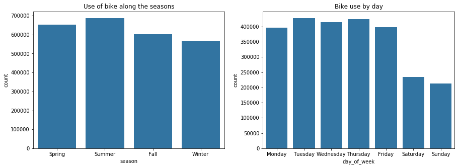

```python
#bar chart for the distribution along the months
plt.figure(figsize = [15, 5])
base_color = sns.color_palette()
season_order = ['Spring', 'Summer', 'Fall', 'Winter']
day_order = ['Monday', 'Tuesday', 'Wednesday', 'Thursday', 'Friday', 'Saturday', 'Sunday']

plt.subplot(1, 2, 1)
sns.countplot(data = df_2019, x='season', order=season_order, color=base_color[0]);
plt.title('Use of bike along the seasons');

plt.subplot(1, 2, 2)
sns.countplot(data = df_2019, x='day_of_week', order=day_order, color=base_color[0]);
plt.title('Bike use by day');
```

## User type

There are much more subscriber user types, but the customer type, spend in average more time with the bikes.

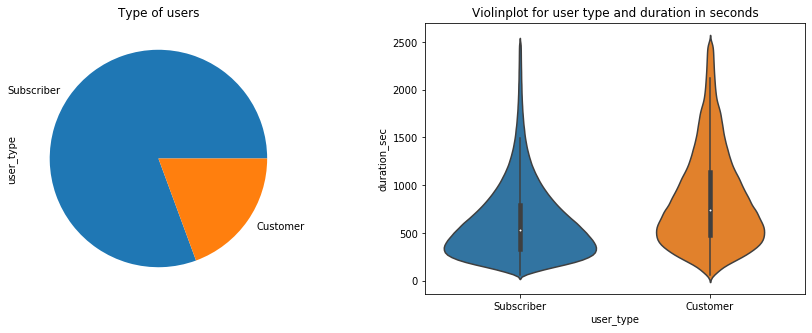

```python
plt.figure(figsize=[15, 5])
season_order = ['Spring', 'Summer', 'Fall', 'Winter']

plt.subplot(1, 2, 1)
df_2019.user_type.value_counts().plot(kind='pie');
plt.title('Type of users');

plt.subplot(1, 2, 2)
duration = df_2019.query('duration_sec <= 2500')
sns.violinplot(data = duration, x = 'user_type', y = 'duration_sec');
plt.title('Violinplot for user type and duration in seconds');
```

## Multivariable visualization

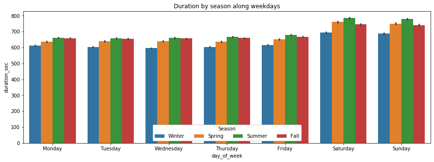

```python
plt.figure(figsize = [15, 5])
ax = sns.barplot(data = duration, x = 'day_of_week', y = 'duration_sec', hue = 'season', order=day_order)
ax.legend(loc = 8, ncol = 4, framealpha = 1, title = 'Season');
plt.title('Duration by season along weekdays');
```